# Big Data Science - R intro and Feature extraction

2017/3/7

## Outline

- Setup on your mac/HPC
- Data strucutes and types in R
- Data Manipulation in R
- Feature Selection with Fselector

## Setup on your mac

[Download R studio](https://www.rstudio.com/products/rstudio/download/)

[Download R](https://www.r-project.org/)

## Setup R on HPC (on Prince)

```
ssh -Y <net_id>@prince.hpc.nyu.edu
srun --x11 --pty /bin/bash
module avail rstudio
rstudio/1.0.136
module load rstudio/1.0.136
rstudio
```

## Setup R on HPC (on dumbo)

```
ssh -Y <net_id>@dumbo.hpc.nyu.edu
module purge
module load R/3.3.2
module load spark/1.6.0
sparkR
```

## R Data Type

R supports a few basic data types: integer, numeric, logical, character/string, factor, and complex Logical – binary, two possible values represented by TRUE and FALSE

```r
x =c(3, 7, 1, 2)
x
```

```
## [1] 3 7 1 2
```

```r
x =c(3, 7, 1, 2)
which(x>2)
```

```
## [1] 1 2
```

## R Data strucute

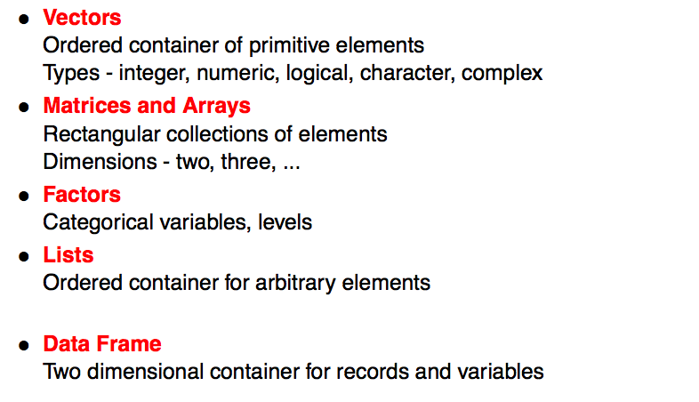

Reference: [UC berkeley stat](http://www.stat.berkeley.edu/~nolan/stat133/Fall05/lectures/RIntro4.pdf)

## Vector

```r
c(3, 2, 1)
```

```
## [1] 3 2 1
```

```r
x=c(bob=3,alice=2,John=1)
names(x)
```

```
## [1] "bob"   "alice" "John"
```

```r
x[0]
```

```
## named numeric(0)
```

```r
x[1]
```

```
## bob
##   3
```

## Matrix

```r
m <- matrix(1:4, nrow = 2)
m
```

```
##      [,1] [,2]
## [1,]    1    3
## [2,]    2    4
```

```r
class(m)
```

```
## [1] "matrix"
```

```r
dim(m)
```

```
## [1] 2 2
```

## Array

```r
yy <- array(1:3, c(2,3,2))
yy
```

```
## , , 1
##
##      [,1] [,2] [,3]
## [1,]    1    3    2
## [2,]    2    1    3
##
## , , 2
##
##      [,1] [,2] [,3]
## [1,]    1    3    2
## [2,]    2    1    3
```

```r
dim(yy)
```

```
## [1] 2 3 2
```

## List

A list is a generic vector containing other objects.

```
## [[1]]
## [1] 2 3 5 4
##
## [[2]]
## [1] "aa" "bb" "cc" "dd" "ee"
##
## [[3]]
## [1]  TRUE FALSE  TRUE FALSE FALSE
##
## [[4]]
## [1] 3
```

Reference: [R Tutorial](http://www.r-tutor.com/r-introduction/list)

## Dataframe

A data frame is used for storing data tables. It is a list of vectors of equal length. For example, the following variable df is a data frame containing three vectors n, s, b.

```
##   n  s     b
## 1 2 aa  TRUE
## 2 3 bb FALSE
## 3 5 cc  TRUE
```

## Data Type Conversion

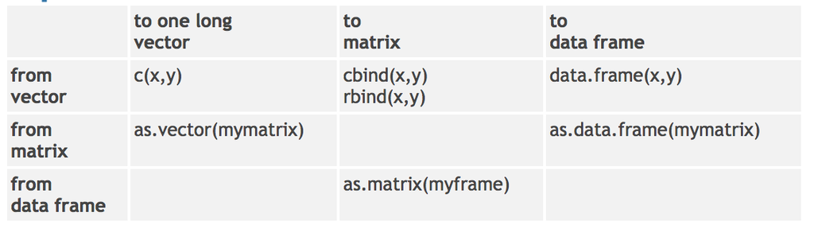

Reference: [Data Type Conversion](http://www.statmethods.net/management/typeconversion.html)

## Data Manuplation in R (Matrix)

Matrix manipulation in R are very useful in Linear Algebra. Below are list of common yet important functions in dealing operations with matrices:

- Transpose - t
- Multiplication - %*%
- Determinant - det()
- Inverse - solve
- Eigenvalues and Eigenvectors - eigen
- Apply function - apply, lapply, sapply

Reference:[Matrix Manuplation](https://nsaunders.wordpress.com/2010/08/20/a-brief-introduction-to-apply-in-r/)

## Data Manuplation in R - (apply)

apply returns a vector or array or list of values obtained by applying a function to margins of an array or matrix

```r
# create a matrix of 10 rows x 2 columns
m <- matrix(c(1:6, 1:12), nrow = 3, ncol = 2)
apply(m, 1:2, function(x) x/2)
```

```
##      [,1] [,2]
## [1,]  0.5  2.0
## [2,]  1.0  2.5
## [3,]  1.5  3.0
```

## Data Manuplation in R - (lapply)

lapply returns a list of the same length as X, each element of which is the result of applying FUN to the corresponding element of X.

```r
l <- list(a = 1:10, b = 11:20)

lapply(l, mean)
```

```
## $a
## [1] 5.5
##
## $b
## [1] 15.5
```

P.S rapply is a recursive version of lapply.

## Data Manuplation in R - (sapply)

sapply is a user-friendly version of lapply by default returning a vector or matrix if appropriate.

```r
# create a list with 2 elements
l <- list(a = 1:10, b = 11:20)
# mean of values using sapply
l.mean <- sapply(l, mean)
# what type of object was returned?
class(l.mean)
```

```
## [1] "numeric"
```

```r
# it's a numeric vector, so we can get element "a" like this
l.mean[['a']]
```

```
## [1] 5.5
```

## Brief Introduction to library

- [e1701](https://cran.r-project.org/web/packages/e1071/index.html)
- [caret](https://topepo.github.io/caret/)
- [FSelector](https://cran.r-project.org/web/packages/FSelector/FSelector.pdf)

## e1701

Functions for latent class analysis, short time Fourier transform, fuzzy clustering, support vector machines, shortest path computation, bagged clustering, naive Bayes classifier, …

## Caret

The caret R package provides tools automatically report on the relevance and importance of attributes in your data and even select the most important features for you.

## FSelector

Functions for selecting attributes from a given dataset. Attribute subset selection is the process of identifying and removing as much of the irrelevant and redundant information as possible.

## Install Packages

```
### go to terminal
sudo R CMD javareconf
install.packages("rJava",type='source')
install.packages("RWeka")
install.packages("FSelector")
```

```r
dyn.load('/Library/Java/JavaVirtualMachines/jdk1.8.0_60.jdk
         /Contents/Home/jre/lib/server/libjvm.dylib')
library("e1071")
library("FSelector")
library("caret")
```

## Feature Selection with Fselector

DEMO!!!!!  
FIND INFO IN THE LINK: goo.gl/jnOvTb